# Non-linear and local methods

Joshua Loftus

2/12/2021

## 2d non-linear classification data

```r
# sample size
n <- 800
# function with zero set that
# defines the perfect (Bayes) decision boundary
true_boundary_function <- function(x1, x2) {
  # experiment with changing this
  thing <- x1^2*x2^3
  (x1^2 + x2^2 - 1)^3 - thing
}
train <- data.frame(
  # change the distribution
  # or scale as needed
  x1 = 1.5*(1 - 2*runif(n)),
  x2 = 1.5*(1 - 2*runif(n))
) %>%
  mutate(
    # labels if classes were perfectly separated
    separable = true_boundary_function(x1,x2) > 0,
    # labels if classes are "noisy"
    y = factor(rbinom(n, 1, 9/10 - (8/10) * as.numeric(separable)))
  )
```

### Plot the data

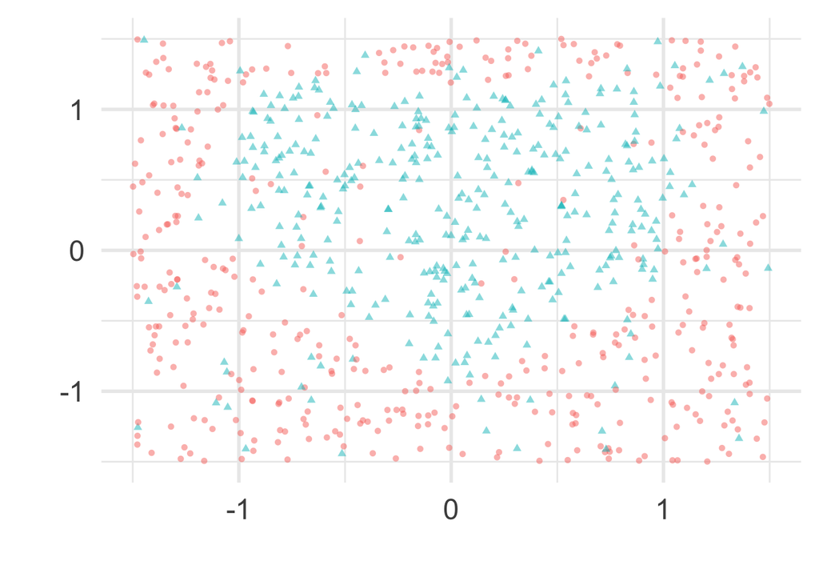

```r
train_plot <-
  ggplot(train, aes(x1, x2)) +
  geom_point(aes(shape = y, color = y),
             alpha = .5, show.legend = FALSE) +
  xlab("") + ylab("")

train_plot
```

### Plot the Bayes decision boundary

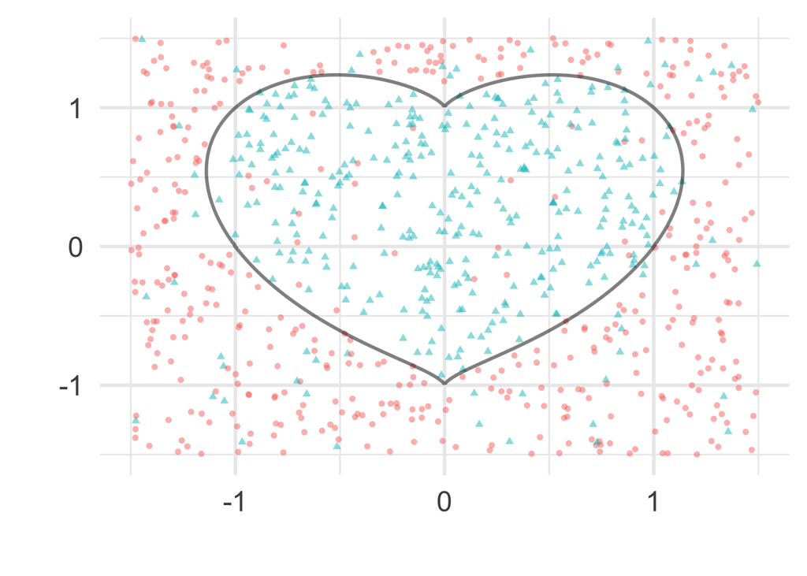

```r
decision_surface <-
  data_grid(train,
          x1 = seq_range(x1, 300, expand = .05),
          x2 = seq_range(x2, 300, expand = .05)) %>%
  mutate(z = true_boundary_function(x1, x2))

boundary_plot <-
  train_plot +
  geom_contour(
    data = decision_surface,
    aes(x1, x2, z=z),
    bins = 2,
    size = 1,
    color = "black",
    alpha = .5)

boundary_plot
```

### How well does linear classification do?

Also try changing the formula to fit a logistic regression model with non-linear transformations of the predictors

```r
# Fit model
logit_model <-
  glm(y ~ x1 + x2 + poly(x1,2) * poly(x2,2), family = "binomial", data = train)
# try formula + poly(x1,2) * poly(x2,2)

# Generate decision boundary
logit_surface <- logit_model %>%
   augment(type.predict = "response",
              newdata = decision_surface)
```

Plot decision boundary of logistic model

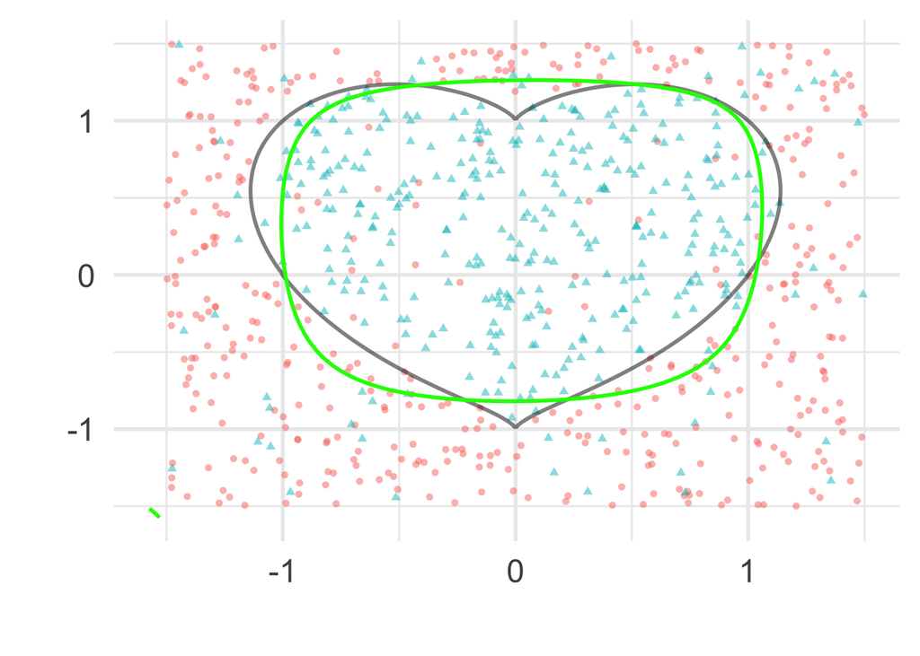

```r
boundary_plot +
  geom_contour(
    data = logit_surface,
    aes(x1, x2, z = .fitted),
    size = 1,
    color = "green",
    bins = 2)
```

```r
summary(logit_model)
```

```
##
## Call:
## glm(formula = y ~ x1 + x2 + poly(x1, 2) * poly(x2, 2), family = "binomial",
##     data = train)
##
## Deviance Residuals:
##     Min       1Q   Median       3Q      Max
## -2.6501  -0.6374  -0.1897   0.5421   3.3260
##
## Coefficients: (2 not defined because of singularities)
##                            Estimate Std. Error z value Pr(>|z|)
## (Intercept)                 -0.4026     0.1067  -3.775  0.00016 ***
## x1                           0.1205     0.1253   0.962  0.33607
## x2                           1.0464     0.1356   7.718 1.18e-14 ***
## poly(x1, 2)1                     NA         NA      NA       NA
## poly(x1, 2)2               -36.2776     3.4786 -10.429  < 2e-16 ***
## poly(x2, 2)1                     NA         NA      NA       NA
## poly(x2, 2)2               -37.7282     3.5567 -10.608  < 2e-16 ***
## poly(x1, 2)1:poly(x2, 2)1   94.8050    91.3022   1.038  0.29910
## poly(x1, 2)2:poly(x2, 2)1 -271.0467    92.3049  -2.936  0.00332 **
## poly(x1, 2)1:poly(x2, 2)2  -91.5844    88.5331  -1.034  0.30092
## poly(x1, 2)2:poly(x2, 2)2  820.6302   102.4940   8.007 1.18e-15 ***
## ---
## Signif. codes:  0 '***' 0.001 '**' 0.01 '*' 0.05 '.' 0.1 ' ' 1
##
## (Dispersion parameter for binomial family taken to be 1)
##
##     Null deviance: 1103.2  on 799  degrees of freedom
## Residual deviance:  634.7  on 791  degrees of freedom
## AIC: 652.7
##
## Number of Fisher Scoring iterations: 5
```

## 1-d smooth regression example

Generate a one-dimensional example with a non-linear relationship

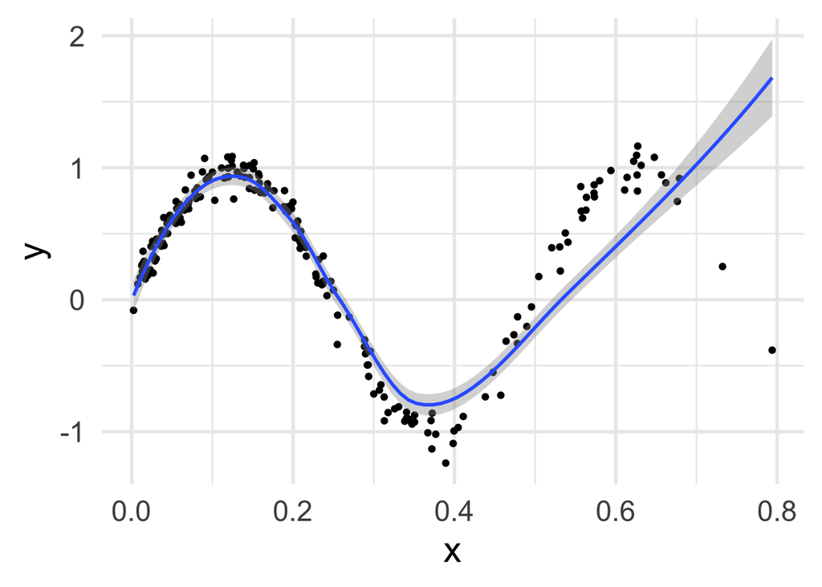

```r
# change this function
f <- function(x) sin(4*pi*x)
n <- 200
train1d <-
  data.frame(
    x = rbeta(n, 1, 3)
    ) %>%
  # change the noise level sd
  mutate(y = f(x) + rnorm(n, sd = .1))

# plot data and loess curve
ggplot(train1d, aes(x, y)) +
  geom_point() +
  geom_smooth()
```

Linear regression with a polynomial transform of x

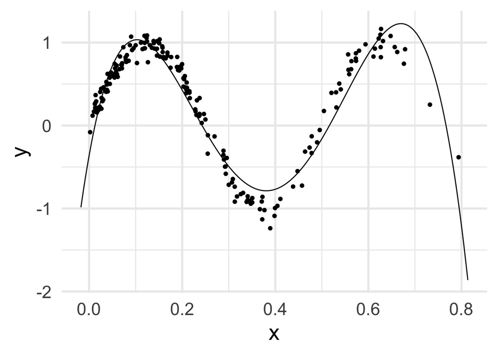

```r
model_lm <- lm(y ~ poly(x, 5), data = train1d)

train1d_grid <-
  data_grid(train1d,
          x = seq_range(c(x, .78), 1000, expand = .05))

augment(model_lm,
        newdata = train1d_grid) %>%
  ggplot(aes(x, y)) +
  geom_point(data = train1d) +
  geom_line(aes(y = .fitted))
```

## Local methods

### Local averages/regression for 1d example

Write functions to compute:

- Average of k-nearest neighbors
- Local regression:
1. Gather the fraction s = k/n of training points whose xi are closest to x0.
2. Assign a weight Ki0 = K(xi,x0) to each point in this neighborhood, so that the point furthest from x0 has weight zero, and the closest has the highest weight. All but these k nearest neighbors get weight zero.
3. Fit a weighted least squares regression of the yi on the xi using the aforementioned weights
4. Use the weighted least squares model to predict for x0

```r
# assume input data has variables x and y
# assume data is sorted on x from smallest to largest
K <- function(x1, x2) {
    # largest if x1 = x2
  1/(1 + 2*abs(x1-x2))
}
local_regression <- function(data, x0, s = .1) {
  n <- nrow(data)
  k <- ceiling(n*s)
  i <- 0
  loop <- TRUE
  while (loop) {
    i <- i + 1
    if (data$x[i] > x0) {
      loop <- FALSE
    }
    if (i >= n) {
      loop <- FALSE
    }
  }
  # i such that
  # data$x[i] > x0
  # but data$x[i-1] <= x0
  local_range <- (i - ceiling(k/2)) : (i + floor(k/2))
  # weight function
  if (min(local_range) < 1) {
    local_range <- 1:k
  } else if (max(local_range) > n) {
    local_range <- (n-k):n
  }

  local_lm <- lm(y ~ x,
                 data = data[local_range, ],
                weights = K(x0, data$x[local_range])
                 )
  sum(coef(local_lm) * c(1, x0))
}
```

Generate predictions from these methods and plot them

```r
train_local <- train1d %>%
  arrange(x)

local_regression(train_local, x0 = .2)
```

```
## [1] 0.5910906
```

Plot

```r
for (i in 1:nrow(train1d_grid)) {
  train1d_grid$.fitted[i] <- local_regression(train_local, x0 = train1d_grid$x[i], s = .1)
}
```

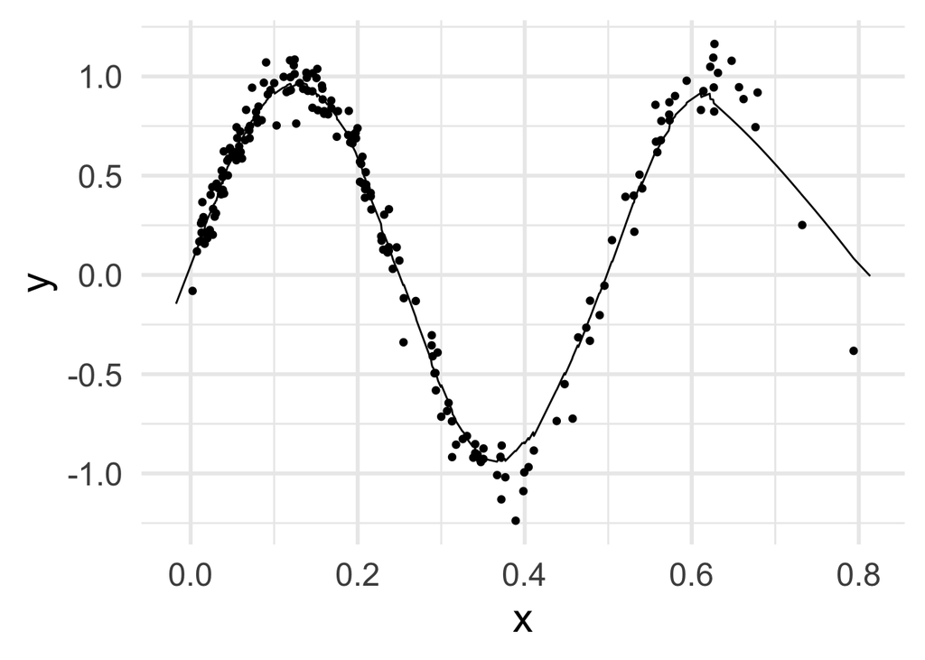

```r
  ggplot(train1d_grid, aes(x, y)) +
  geom_point(data = train1d) +
  geom_line(aes(y = .fitted))
```

### Classify 2d example with k-nearest neighbors

Write a function to implement k-NN classification

You may use matrix operations and simple functions like `sort` but not any more sophisticated built-in R functions (or libraries)

Hint: https://en.wikipedia.org/wiki/Euclidean_distance_matrix#Relation_to_Gram_matrix

```r
Dist <- function(x1, x2) {
  # Euclidean or L2
  sqrt(sum(abs(x1-x2)^2))
}
# Requires a distance function D
# to already be defined
knn <- function(x0, k, x, y) {
  n <- nrow(x)
  distances <- rep(0, n)
  for (i in 1:n) {
    distances[i] <- Dist(x0, x[i,])
  }
  k_neighborhood <- order(distances, decreasing = FALSE)[1:k]
  levels(y)[which.max(table(y[k_neighborhood]))]
}
```

```r
# Smaller dataset so code runs faster
subsample <- sample(1:nrow(train), 300)
x <- train[subsample, 1:2]
y <- train$y[subsample]
output <- knn(x0 = c(0,2), k = 5, x, y)
output
```

```
## [1] "0"
```

Classify the training data

```r
knn <- function(k, x, y, progress = TRUE) {
  n <- nrow(x)
  distances <- matrix(0, nrow = n, ncol = n)
  if (progress) pb <- txtProgressBar(style = 3)
  for (i in 1:(n-1)) {
    for (j in (i+1):n) {
      distances[i,j] <- Dist(x[j,], x[i,])
    }
    if (progress) setTxtProgressBar(pb, i/(n-1))
  }
  classifications <- rep(NA, n)
  for (i in 1:n) {
    k_neighborhood <- order(distances[i,], decreasing = FALSE)[1:k]
    max_class <- which.max(table(y[k_neighborhood]))
    classifications[i] <- levels(y)[max_class]
  }
  classifications
}
```

```r
classifications <- knn(3, x, y, progress = F)
```

```r
mean(y != classifications)
```

```
## [1] 0.43
```

```r
classifications <- knn(11, x, y, progress = F)
```

```r
mean(y != classifications)
```

```
## [1] 0.4266667
```

```r
classifications <- knn(19, x, y, progress = F)
```

```r
mean(y != classifications)
```

```
## [1] 0.4166667
```

```r
# need a faster implementation for this
```